# p8105_hw3_sal2222

Stephen Lewandowski

October 15, 2018

# Problem 1: BRFSS

I will load and format the Behavioral Risk Factors Surveillance System (BRFSS) for Selected Metropolitan Area Risk Trends (SMART) data from the p8105.datasets package.

```r
data("brfss_smart2010")

brfss <- brfss_smart2010 %>%
  janitor::clean_names() %>%
  filter(topic == "Overall Health") %>%
  select(-c(class, topic, question, sample_size, confidence_limit_low:geo_location)) %>%
  spread(key = response, value = data_value) %>%
  janitor::clean_names() %>%
  rename(state = locationabbr, county = locationdesc) %>%
  separate(county, into = c("remove", "county"), sep = "- ") %>%
  select(year, state, county, poor, fair, good, very_good, excellent)

brfss
```

```
## # A tibble: 2,125 x 8
##     year state county                  poor  fair  good very_good excellent
##    <int> <chr> <chr>                  <dbl> <dbl> <dbl>     <dbl>     <dbl>
##  1  2002 AK    Anchorage Municipality   5.9   8.6  23.8      33.7      27.9
##  2  2002 AL    Jefferson County         5.9  12.1  32.7      30.9      18.5
##  3  2002 AR    Pulaski County           4.2  12.5  29.9      29.3      24.1
##  4  2002 AZ    Maricopa County          4.6  10.3  26.9      36.6      21.6
##  5  2002 AZ    Pima County              3.9   7.5  31.9      30.1      26.6
##  6  2002 CA    Los Angeles County       4.5  14.3  28.7      29.8      22.7
##  7  2002 CO    Adams County             4.2  14.4  29        31.2      21.2
##  8  2002 CO    Arapahoe County          2.1   8    29.3      35.2      25.5
##  9  2002 CO    Denver County            3    11.1  36.6      27.1      22.2
## 10  2002 CO    Jefferson County         2.4  11.4  26.3      36.6      23.4
## # ... with 2,115 more rows
```

I will answer questions using this BRFSS dataset.

*In 2002, which states were observed at 7 locations?*

```r
brfss %>%
  filter(year == 2002) %>%
  group_by(state) %>%
  summarise(number = n()) %>%
  filter(number == 7)
```

```
## # A tibble: 3 x 2
##   state number
##   <chr>  <int>
## 1 CT         7
## 2 FL         7
## 3 NC         7
```

In 2002, 7 locations were observed in **Connecticut, Florida, and North Carolina**.

*Make a “spaghetti plot” that shows the number of observations in each state from 2002 to 2010.*

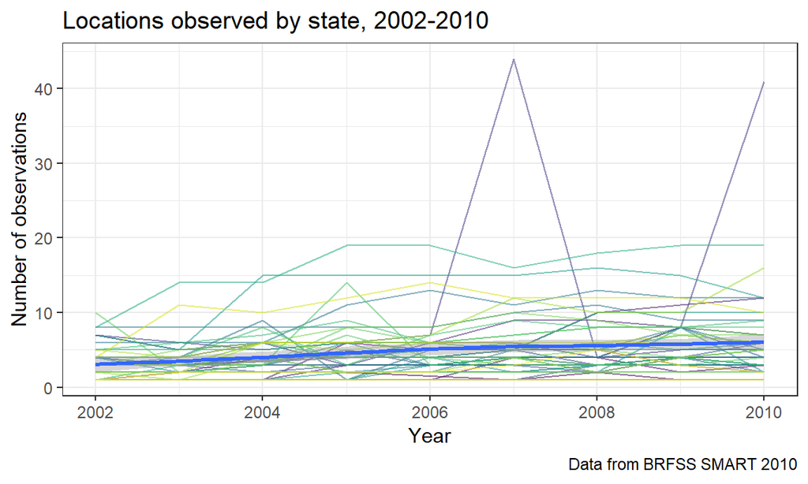

```r
brfss %>%
  group_by(state, year) %>%
  summarise(number = n()) %>%
  ggplot(aes(x = year, y = number)) +
    geom_line(aes(color = state, alpha = 0.5)) +
    geom_smooth(method = "loess", se = TRUE) +
    labs(
      title = "Locations observed by state, 2002-2010",
      x = "Year",
      y = "Number of observations",
      caption = "Data from BRFSS SMART 2010"
    ) +
    viridis::scale_color_viridis(
      name = "State",
    discrete = TRUE
    ) +
    theme(legend.position = "none")
```

This plot is useful for showing the general trend of locations by state from 2002 to 2010. However, it is very difficult to identify individual states, and a legend for all of the states occupies too much space, if included. A loess smoothed conditional mean curve shows a very gradual increase in number of locations observed by state over this time period.

*Make a table showing, for the years 2002, 2006, and 2010, the mean and standard deviation of the proportion of “Excellent” responses across locations in NY State.*

```r
brfss %>%
  filter(year == 2002 | 2006 | 2010) %>%
  filter(state == "NY") %>%
  group_by(year) %>%
  summarise(mean_excellent = mean(excellent),
            sd_excellent = sd(excellent)) %>%
  knitr::kable(digits = 1, caption = "Proportion of “Excellent” responses across locations in NY State")
```

Proportion of “Excellent” responses across locations in NY State

| year | mean_excellent | sd_excellent |
| --- | --- | --- |
| 2002 | 24.0 | 4.5 |
| 2003 | 21.9 | 4.6 |
| 2004 | 21.2 | 5.1 |
| 2005 | 21.7 | 5.1 |
| 2006 | 22.5 | 4.0 |
| 2007 | 21.1 | 5.1 |
| 2008 | 22.8 | 4.5 |
| 2009 | 23.3 | 4.3 |
| 2010 | 22.7 | 3.6 |

The table above shows the mean and standard deviation of the proportion of “Excellent” responses across locations in NY State. Nothing in particular stands out from the results. The highest proportion of “Excellent” responses occurred in 2002 (24.0%) and the lowest occurred in 2007 (21.1%).

*For each year and state, compute the average proportion in each response category (taking the average across locations in a state). Make a five-panel plot that shows, for each response category separately, the distribution of these state-level averages over time*

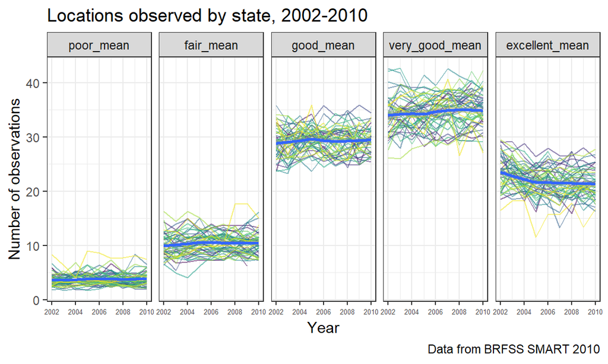

```r
brfss %>%
  select(-county) %>%
  group_by(year, state) %>%
  summarise_all(funs(mean = "mean")) %>%
  gather(key = rating, value = mean_proportion, poor_mean:excellent_mean) %>%
  mutate(rating =
      factor(rating, c("poor_mean", "fair_mean", "good_mean", "very_good_mean", "excellent_mean"))) %>%
  ggplot(aes(x = year, y = mean_proportion)) +
    geom_line(aes(color = state, alpha = 0.5)) +
    geom_smooth(method = "loess", se = TRUE) +
    facet_grid(~rating) +
    labs(
      title = "Locations observed by state, 2002-2010",
      x = "Year",
      y = "Number of observations",
      caption = "Data from BRFSS SMART 2010"
    ) +
    viridis::scale_color_viridis(
      name = "State",
    discrete = TRUE
    ) +
    theme(legend.position = "none",
          axis.text.x = element_text(size = 5))
```

# Problem 2: Instacart

```r
data("instacart")
instacart
```

```
## # A tibble: 1,384,617 x 15
##    order_id product_id add_to_cart_ord~ reordered user_id eval_set
##       <int>      <int>            <int>     <int>   <int> <chr>
##  1        1      49302                1         1  112108 train
##  2        1      11109                2         1  112108 train
##  3        1      10246                3         0  112108 train
##  4        1      49683                4         0  112108 train
##  5        1      43633                5         1  112108 train
##  6        1      13176                6         0  112108 train
##  7        1      47209                7         0  112108 train
##  8        1      22035                8         1  112108 train
##  9       36      39612                1         0   79431 train
## 10       36      19660                2         1   79431 train
## # ... with 1,384,607 more rows, and 9 more variables: order_number <int>,
## #   order_dow <int>, order_hour_of_day <int>,
## #   days_since_prior_order <int>, product_name <chr>, aisle_id <int>,
## #   department_id <int>, aisle <chr>, department <chr>
```

This Instacart Online Grocery Shopping 2017 dataset comes from an anonymized dataset with over 3 million online grocery orders from more than 200,000 Instacart users. This version of the data contains 1384617 observations of a product in an order. There are 15 variables in this dataset that describe order, product, and customer identifiers, the order in which the item was added to a user’s cart, whether the product had been previously ordered by the user, the order sequence from the user, the hour and day of the week the order was placed, day since prior order, as well as product name, aisle, and department information.

*The goal is to do some exploration of this dataset. To that end, write a short description of the dataset, noting the size and structure of the data, describing some key variables, and giving illstrative examples of observations. Then, do or answer the following (commenting on the results of each):*

*How many aisles are there, and which aisles are the most items ordered from?*

*Make a plot that shows the number of items ordered in each aisle. Order aisles sensibly, and organize your plot so others can read it.*

*Make a table showing the most popular item aisles “baking ingredients”, “dog food care”, and “packaged vegetables fruits”*

*Make a table showing the mean hour of the day at which Pink Lady Apples and Coffee Ice Cream are ordered on each day of the week; format this table for human readers (i.e. produce a 2 x 7 table).*

# Problem 3: NY NOAA